# Property price analysis

C Chinogurei

2024-09-21

## Introduction

In Cape Town, property prices vary significantly by neighborhood, with some areas being more expensive than others. The most expensive areas include Camps Bay, Clifton, Constantia, and parts of the City Bowl like Oranjezicht. These areas offer luxury homes, ocean views, exclusivity, and proximity to amenities, driving their high property values.

More affordable neighborhoods can be found in the South Peninsula, such as Muizenberg and Fish Hoek, and in the Northern Suburbs like Brackenfell and Bellville. These areas offer family-friendly environments with good infrastructure and are popular among first-time homebuyers seeking more reasonably priced properties.

The differences in property prices are largely influenced by factors like location, amenities, lifestyle appeal, and scenic views. The luxury offerings and exclusivity of areas like the Atlantic Seaboard lead to higher prices, while inland or suburban areas provide more budget-friendly housing options.

# Quick summary

In Cape Town, property prices range widely, from as low as R299,000 in more affordable areas to as high as R53 million in the city’s most luxurious neighborhoods, with the average price around R4.2 million. This large variation is influenced by a combination of factors such as location, proximity to natural attractions, socio-economic status, and the amenities available in each area.

|  | location | price | bedroom | size | Area_Categorized | area |
| --- | --- | --- | --- | --- | --- | --- |
|  | Sandown : 320 | Min. : 299000 | Min. : 1.000 | Min. : 24.0 | Low size Area : 709 | Outside Cape Town :9895 |
|  | Dana Bay : 150 | 1st Qu.: 1845000 | 1st Qu.: 3.000 | 1st Qu.:270.8 | Mid size Area :2486 | Southern Suburbs : 815 |
|  | Struisbaai : 122 | Median : 2990000 | Median : 3.000 | Median :465.0 | High size Area:3042 | West Coast Suburbs : 807 |
|  | Stilbaai Wes: 121 | Mean : 4171499 | Mean : 3.527 | Mean :477.5 | Luxury Area :4571 | Northern Suburbs : 569 |
|  | Laguna : 104 | 3rd Qu.: 4495000 | 3rd Qu.: 4.000 | 3rd Qu.:653.0 | NA’s :1986 | Cape Flats (South East suburbs): 292 |
|  | Vredenburg : 96 | Max. :52500000 | Max. :25.000 | Max. :999.0 | NA | City Bowl : 192 |
|  | (Other) :11881 | NA | NA | NA’s :1986 | NA | (Other) : 224 |

| area | avg_price | avg_bedrooms | avg_erf_size | count |
| --- | --- | --- | --- | --- |
| Atlantic Seaboard | 19648721 | 4.209302 | 501.6182 | 129 |
| Cape Flats (South East suburbs) | 1608604 | 3.482877 | 304.1568 | 292 |
| City Bowl | 7207432 | 3.890625 | 289.2707 | 192 |
| Eastern Suburbs | 2584376 | 3.252632 | 345.8000 | 95 |
| Northern Suburbs | 2882934 | 3.507909 | 444.7456 | 569 |
| Outside Cape Town | 3915329 | 3.485194 | 499.1137 | 9895 |
| Southern Suburbs | 6465041 | 3.773006 | 472.2286 | 815 |
| West Coast Suburbs | 3822605 | 3.662949 | 392.9700 | 807 |

The largest average erf sizes are found in properties outside Cape Town (499.2 sqm) and in the Atlantic Seaboard area, while the Cape Flats and City Bowl have some of the smallest plots. This table highlights that higher property prices are often associated with prime locations and views, such as the Atlantic Seaboard, whereas more affordable properties can be found in suburban or less centrally located areas, such as the Cape Flats and Northern Suburbs.

location

Atlantic Seaboard

Cape Flats (South East suburbs)

[figure not shown]

City Bowl

[figure not shown]

Eastern Suburbs

Northern Suburbs

[figure not shown]

Southern Suburbs

[figure not shown]

West Coast Suburbs

[figure not shown]

## What price margin can you expect depending on your home preferences?

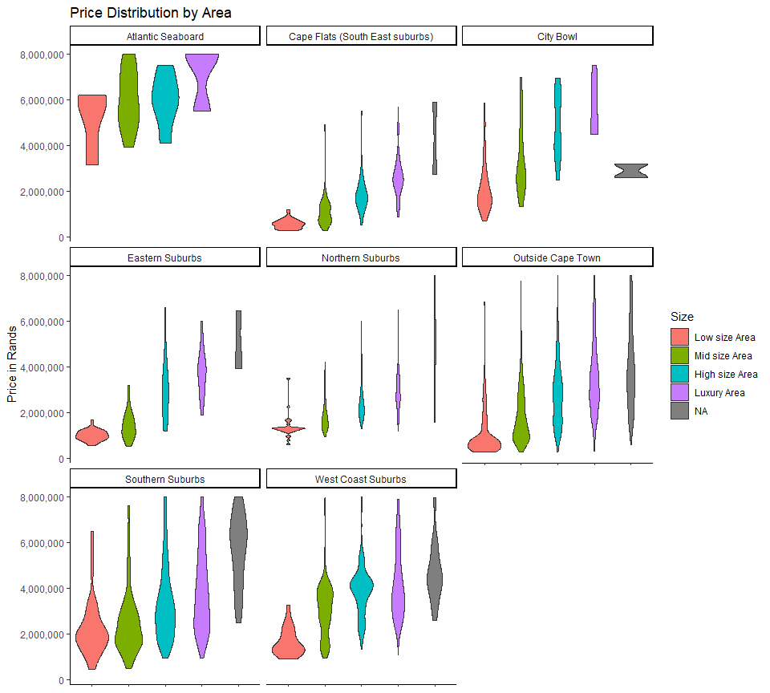

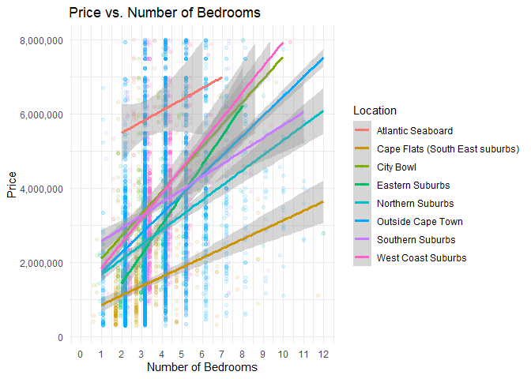

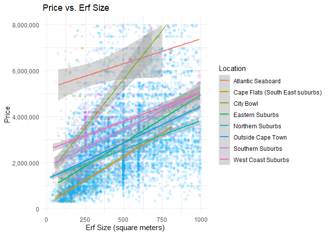